# Hi-C contig processing

Alice Risely

23/10/2023

# 1 Info

Rmarkdown report for the analysis to go with the manuscript “AMR gene presence predicts plasmid network structure in wastewater” by Alice Risely, Arthur Newbury, Thibault Stalder, Benno I. Simmons, Eva M. Top, Angus Buckling, and Dirk Sanders

Data generated by: Stalder et al. “Linking the resistome and plasmidome to the microbiome.” The ISME journal 13.10 (2019): 2437-2446.

Contig processing steps performed under ‘Contig processing’. See Fig S3 for flowchart:

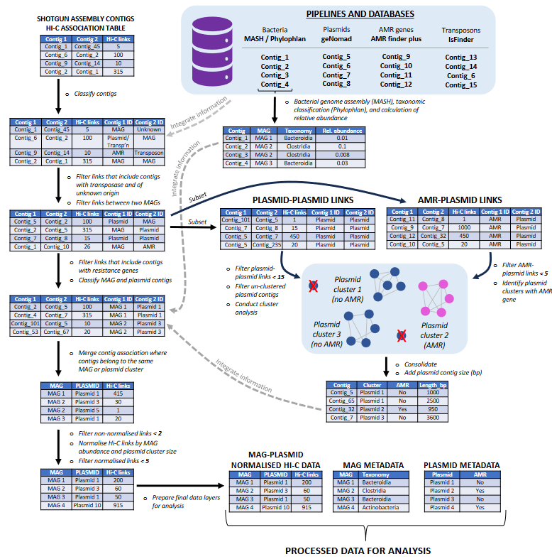

### 1.0.1 Import packages

```r
library(tidyverse)
library(data.table)
library(phyloseq)
library(igraph)
library(network)
library(expss)
library(here)
library(ggnetwork)
library(RColorBrewer)
library(ggvenn)
library(ggrepel)
library(ggpubr)

memory.limit(1000000)
```

```
## [1] 1e+06
```

# 2 Import data

#### 2.0.0.1 Import HiC data

- NOT RUN
- First few basic filtering steps are skipped as they take a lot of RAM.
- These include filtering out links that are duplicates and between the same contigs.

```r
## import association table

WW_links <- read.delim(here("DATA","WW_links.txt"), header=FALSE)
WW_links_DT<-as.data.table(WW_links) # convert to data table
rm(WW_links)
```

#### 2.0.0.2 Remove duplicates

```r
# remove contigs attached to themselves

WW_links_DT$self_link<-WW_links_DT$V1 == WW_links_DT$V2
WW_links_DT2<-subset(WW_links_DT, self_link == F)

## remove duplicates
WW_links_filt2<-WW_links_DT2 %>%
  group_by(grp = paste(pmax(V1, V2), pmin(V1, V2), sep = "_")) %>%
  slice(1) %>%
  ungroup() %>%
  select(-grp)
```

- Now import pre-filtered HiC links dataframe, called “WW_links_filt2”
- All steps from this point largely involve filtering this dataset of noise so that by the end, only meaningful links remain for analysis

```r
# import dataset where reverse dulplicates have been excluded, as well as any contigs attached to themselves.

setwd("C:/Users/risel/Dropbox/Sommer postdoc/Plasmid project/PlasmidProjectAnalysis/Updated analysis2")
WW_links_filt2<-readRDS("DATA/WW_links_filt.RDS")

head(WW_links_filt2)
```

| V1 | V2 | V3 | self_link |
| --- | --- | --- | --- |
| k141_1000386 | k141_1000196 | 1 | FALSE |
| k141_1000616 | k141_1000543 | 1 | FALSE |
| k141_1000630 | k141_1000774 | 1 | FALSE |
| k141_1000590 | k141_1000833 | 3 | FALSE |
| k141_1000728 | k141_1001032 | 1 | FALSE |
| k141_1001172 | k141_1000706 | 1 | FALSE |

```r
dim(WW_links_filt2) # 28 million rows
```

```
## [1] 28111659        4
```

#### 2.0.0.3 Import MAG contigs

```r
setwd(here("DATA", "MAGS"))

myfiles<-list.files()
myfiles[1:5]
```

```
## [1] "bin_1.fasta"   "bin_10.fasta"  "bin_100.fasta" "bin_101.fasta"
## [5] "bin_102.fasta"
```

```r
dataFiles <- lapply(myfiles, read.table)
myfiles<-str_remove(myfiles, ".fasta") # remove 'fasta' string

length(dataFiles) #379 MAGs
```

```
## [1] 379
```

```r
#change names
names(dataFiles)<-myfiles

## loop to extract contigs per cluster data

mag_list<-list()

for (i in 1:length(myfiles)){

  cluster_x<-dataFiles[[i]]
  selectedRows <- cluster_x[grep(">k141_", cluster_x$V1), ]
  contigs<-substring(selectedRows, 2)
  df<-data.frame(contigs)
  df$cluster<-myfiles[i]
  mag_list[[i]]<-df
}

names(mag_list)<-myfiles
mag_data<-do.call(rbind, mag_list)
mag_assignment<-mag_data
mag_list <- as.character(mag_assignment$contigs)

setwd("C:/Users/risel/Dropbox/Sommer postdoc/Plasmid project/PlasmidProjectAnalysis/Updated analysis2")
```

#### 2.0.0.4 Import predited plasmid IDs

- Import results from Genomad

```r
genomad_plasmids <- read.delim("C:/Users/risel/Dropbox/Sommer postdoc/Plasmid project/PlasmidProjectAnalysis/Updated analysis2/DATA/wastewater_pw_rerun_contigs_plasmid_summary.tsv")

plasmid_list<- as.character(genomad_plasmids$seq_name)
```

#### 2.0.0.5 Import transposon list

```r
transposons <- read.delim(here("DATA","ISfinder_best_match_transposons.csv"), header=TRUE, sep = ",")
transposon_list<-as.character(transposons$contig)
```

#### 2.0.0.6 Import resistance gene list

```r
# import AMR gene data
amr_genes <- read.delim(here("DATA","amr_contigs_plassclass_and_plasflow.tsv"))
amr_genes <-amr_genes[,c("contig", "Gene.symbol", "Sequence.name", "Element.type", "Element.subtype")]
```

#### 2.0.0.7 Summarize contig assigments with Venn Diagram

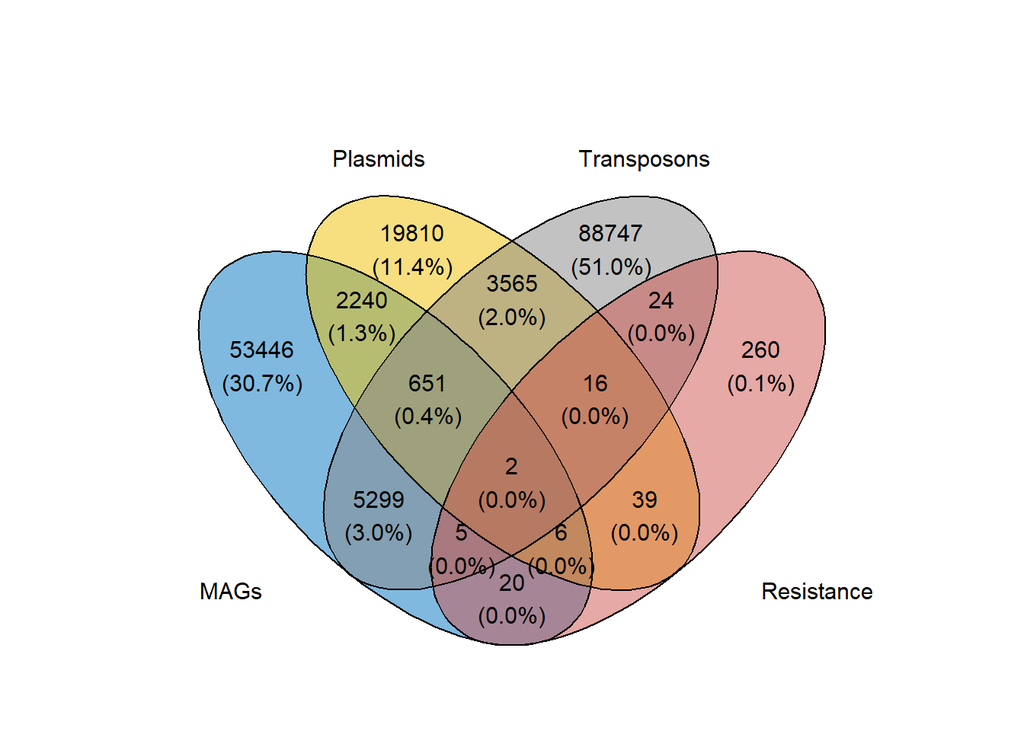

```r
## generate list of all unique contigs

allContigs<-c(unique(WW_links_filt2$V1), unique(WW_links_filt2$V2))
allContigs<-unique(allContigs)

mag_list2<- mag_list[mag_list%in%allContigs]
plasmid_list2<- plasmid_list[plasmid_list%in%allContigs]
transposon_list2<- transposon_list[transposon_list%in%allContigs]
resistance_list2<- amr_genes$contig[amr_genes$contig%in%allContigs]


x <- list(
  MAGs = mag_list2,
  Plasmids = plasmid_list2,
  Transposons = transposon_list2,
  Resistance = resistance_list2
  )

ggvenn(
  x,
 fill_color = c("#0073C2FF", "#EFC000FF", "#868686FF", "#CD534CFF"),
  stroke_size = 0.5, set_name_size = 4
  )
```

# 3 Filter and assign identity

## 3.1 Remove links that involve an unidentified contigs

- Assign all contigs to whether they are a MAG, Plasmid, or resistance gene.

```r
allContigs_df<-data.frame(allContigs)
names(allContigs_df)<-"Contig"

allContigs_df$MAG<- allContigs_df$Contig %in% mag_list
allContigs_df$Plasmid<- allContigs_df$Contig %in% plasmid_list
allContigs_df$Transposon<- allContigs_df$Contig %in% transposon_list
allContigs_df$Resistance<- allContigs_df$Contig %in% amr_genes$contig

allContigs_df$Remove<- allContigs_df$MAG==F & allContigs_df$Plasmid==F &  allContigs_df$Resistance==F

allContigs_filt<-subset(allContigs_df, Remove == F)
```

- Remove links from HiC links dataframe between contigs that are not identified as anything.
- Because we are not interested in these.

```r
WW_links_filt2$Keep<- (WW_links_filt2$V1 %in% allContigs_filt$Contig) & (WW_links_filt2$V2 %in% allContigs_filt$Contig)

WW_links_filt3<-subset(WW_links_filt2, Keep == T)
```

## 3.2 Remove transposons

- Remove any links that involve a transposon

```r
WW_links_filt3$Transposon <- WW_links_filt3$V1 %in% transposon_list | WW_links_filt3$V2 %in% transposon_list
WW_links_filt4<- subset(WW_links_filt3, Transposon == F)
```

- So far removed:links that are 1) duplicates, 2) contigs attached to themselves, 3) involve transposons, 4) involve any unidentifiable contigs (not mags/plasmids/AMR, etc)

## 3.3 Venn diagram after filtering transposons

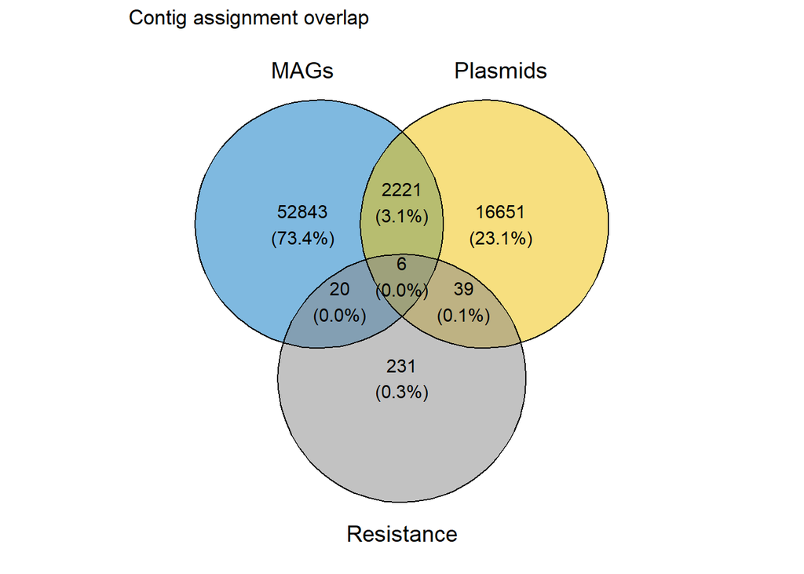

```r
## list of contigs left
allContigs<-c(unique(WW_links_filt4$V1), unique(WW_links_filt4$V2))
allContigs<-unique(allContigs)

## venn diagram

mag_list2<- mag_list[mag_list%in%allContigs]
plasmid_list2<- plasmid_list[plasmid_list%in%allContigs]
resistance_list2<- amr_genes$contig[amr_genes$contig%in%allContigs]


x <- list(
  MAGs = mag_list2,
  Plasmids = plasmid_list2,
  Resistance = resistance_list2
  )

ggvenn(
  x,
  fill_color = c("#0073C2FF", "#EFC000FF", "#868686FF", "#CD534CFF"),
  stroke_size = 0.5, set_name_size = 5, text_size = 4
  )+ggtitle("Contig assignment overlap")
```